# Conteúdo

1. Introdução  
   1.1. Dataset  
   1.2 Variáveis
2. Pré-Processamento
3. Análise Exploratória  
   3.1 Renda  
   3.2 Renda e Sexo  
   3.3 Tese de hipótese  
   3.4 Renda, Sexo e etnina  
   3.5 Correlação salário e estudos  
   3.6 Renda por estado  
   3.7 Renda Distrito Federal  
   3.8 Estado e estudos
4. Conclusão  
   4.1 Insights  
   4.2 Hipóteses

# 1. Introdução

### 1.1 Pesquisa Nacional por Amostra de Domicílios - 2015

A **Pesquisa Nacional por Amostra de Domicílios - PNAD** investiga anualmente, de forma permanente, características gerais da população, de educação, trabalho, rendimento e habitação e outras, com periodicidade variável, de acordo com as necessidades de informação para o país, como as características sobre migração, fecundidade, nupcialidade, saúde, segurança alimentar, entre outros temas. O levantamento dessas estatísticas constitui, ao longo dos 49 anos de realização da pesquisa, um importante instrumento para formulação, validação e avaliação de políticas orientadas para o desenvolvimento socioeconômico e a melhoria das condições de vida no Brasil.

```python
import warnings
warnings.filterwarnings("ignore")
```

### 1.2 Variáveis utilizadas

### Renda

Rendimento mensal do trabalho principal para pessoas de 10 anos ou mais de idade.

### Idade

Idade do morador na data de referência em anos.

### Altura (elaboração própria)

Altura do morador em metros.

### UF

| Código | Descrição |
| --- | --- |
| 11 | Rondônia |
| 12 | Acre |
| 13 | Amazonas |
| 14 | Roraima |
| 15 | Pará |
| 16 | Amapá |
| 17 | Tocantins |
| 21 | Maranhão |
| 22 | Piauí |
| 23 | Ceará |
| 24 | Rio Grande do Norte |
| 25 | Paraíba |
| 26 | Pernambuco |
| 27 | Alagoas |
| 28 | Sergipe |
| 29 | Bahia |
| 31 | Minas Gerais |
| 32 | Espírito Santo |
| 33 | Rio de Janeiro |
| 35 | São Paulo |
| 41 | Paraná |
| 42 | Santa Catarina |
| 43 | Rio Grande do Sul |
| 50 | Mato Grosso do Sul |
| 51 | Mato Grosso |
| 52 | Goiás |
| 53 | Distrito Federal |

### Sexo

| Código | Descrição |
| --- | --- |
| 0 | Masculino |
| 1 | Feminino |

### Anos de Estudo

| Código | Descrição |
| --- | --- |
| 1 | Sem instrução e menos de 1 ano |
| 2 | 1 ano |
| 3 | 2 anos |
| 4 | 3 anos |
| 5 | 4 anos |
| 6 | 5 anos |
| 7 | 6 anos |
| 8 | 7 anos |
| 9 | 8 anos |
| 10 | 9 anos |
| 11 | 10 anos |
| 12 | 11 anos |
| 13 | 12 anos |
| 14 | 13 anos |
| 15 | 14 anos |
| 16 | 15 anos ou mais |
| 17 | Não determinados |
|  | Não aplicável |

### Cor

| Código | Descrição |
| --- | --- |
| 0 | Indígena |
| 2 | Branca |
| 4 | Preta |
| 6 | Amarela |
| 8 | Parda |
| 9 | Sem declaração |

- Dicionáros das variáveis

```python
sexo = {
    0: 'Masculino',
    1: 'Feminino'
}
cor = {
    0: 'Indígena',
    2: 'Branca',
    4: 'Preta',
    6: 'Amarela',
    8: 'Parda',
    9: 'Sem declaração'
}
anos_de_estudo = {
    1: 'Sem instrução e menos de 1 ano',
    2: '1 ano',
    3: '2 anos',
    4: '3 anos',
    5: '4 anos',
    6: '5 anos',
    7: '6 anos',
    8: '7 anos',
    9: '8 anos',
    10: '9 anos',
    11: '10 anos',
    12: '11 anos',
    13: '12 anos',
    14: '13 anos',
    15: '14 anos',
    16: '15 anos ou mais',
    17: 'Não determinados'
}
uf = {
    11: 'Rondônia',
    12: 'Acre',
    13: 'Amazonas',
    14: 'Roraima',
    15: 'Pará',
    16: 'Amapá',
    17: 'Tocantins',
    21: 'Maranhão',
    22: 'Piauí',
    23: 'Ceará',
    24: 'Rio Grande do Norte',
    25: 'Paraíba',
    26: 'Pernambuco',
    27: 'Alagoas',
    28: 'Sergipe',
    29: 'Bahia',
    31: 'Minas Gerais',
    32: 'Espírito Santo',
    33: 'Rio de Janeiro',
    35: 'São Paulo',
    41: 'Paraná',
    42: 'Santa Catarina',
    43: 'Rio Grande do Sul',
    50: 'Mato Grosso do Sul',
    51: 'Mato Grosso',
    52: 'Goiás',
    53: 'Distrito Federal'
}
```

Classes de renda:

**A** ► Acima de 25 SM

**B** ► De 15 a 25 SM

**C** ► De 5 a 15 SM

**D** ► De 2 a 5 SM

**E** ► Até 2 SM

- Importando dados

```python
import pandas as pd
import seaborn as sns
import matplotlib.pyplot as plt
import numpy as np
sns.set(font_scale=1.2)
sns.set_style('white')
sns.set_palette("Blues_r")
import warnings
warnings.filterwarnings("ignore")
```

```python
dados = pd.read_csv('../Data/dados.csv')
dados.head()
```

|  | UF | Sexo | Idade | Cor | Anos de Estudo | Renda | Altura |
| --- | --- | --- | --- | --- | --- | --- | --- |
| 0 | 11 | 0 | 23 | 8 | 12 | 800 | 1.603808 |
| 1 | 11 | 1 | 23 | 2 | 12 | 1150 | 1.739790 |
| 2 | 11 | 1 | 35 | 8 | 15 | 880 | 1.760444 |
| 3 | 11 | 0 | 46 | 2 | 6 | 3500 | 1.783158 |
| 4 | 11 | 1 | 47 | 8 | 9 | 150 | 1.690631 |

# 2. Pré-processamento dos dados

- Renomeando colunas

```python
#renomeando as colunas
dados = dados.replace({'UF': uf,'Sexo' : sexo, 'Cor' : cor})
dados
```

|  | UF | Sexo | Idade | Cor | Anos de Estudo | Renda | Altura |
| --- | --- | --- | --- | --- | --- | --- | --- |
| 0 | Rondônia | Masculino | 23 | Parda | 12 | 800 | 1.603808 |
| 1 | Rondônia | Feminino | 23 | Branca | 12 | 1150 | 1.739790 |
| 2 | Rondônia | Feminino | 35 | Parda | 15 | 880 | 1.760444 |
| 3 | Rondônia | Masculino | 46 | Branca | 6 | 3500 | 1.783158 |
| 4 | Rondônia | Feminino | 47 | Parda | 9 | 150 | 1.690631 |
| ... | ... | ... | ... | ... | ... | ... | ... |
| 76835 | Distrito Federal | Feminino | 46 | Branca | 11 | 812 | 1.687030 |
| 76836 | Distrito Federal | Masculino | 30 | Preta | 7 | 1500 | 1.792934 |
| 76837 | Distrito Federal | Masculino | 32 | Parda | 12 | 1300 | 1.830587 |
| 76838 | Distrito Federal | Masculino | 57 | Parda | 4 | 1500 | 1.726344 |
| 76839 | Distrito Federal | Masculino | 38 | Parda | 4 | 900 | 1.658305 |

76840 rows × 7 columns

- Obtendo informações dos dados

```python
#exibindo informações dos dados
dados.info()
```

```
<class 'pandas.core.frame.DataFrame'>
RangeIndex: 76840 entries, 0 to 76839
Data columns (total 7 columns):
 #   Column          Non-Null Count  Dtype
---  ------          --------------  -----
 0   UF              76840 non-null  object
 1   Sexo            76840 non-null  object
 2   Idade           76840 non-null  int64
 3   Cor             76840 non-null  object
 4   Anos de Estudo  76840 non-null  int64
 5   Renda           76840 non-null  int64
 6   Altura          76840 non-null  float64
dtypes: float64(1), int64(3), object(3)
memory usage: 4.1+ MB
```

- Observação: A coluna altura foi removida, pois ela tinha sido inserida afim de testes estatísticos.

```python
#Apagando coluna altura
dados.drop(columns=['Altura'], inplace=True)
```

- Definindo os valores em reais

Usand dados.Renda.min(), e max() para pegar o menor valor e o maior.

```python
#criando classe de acordo com o salário
classe = [
    dados.Renda.min(),
    2*788,
    5*788,
    15*788,
    25*788,
    dados.Renda.max()
]
classe
```

```
[0, 1576, 3940, 11820, 19700, 200000]
```

- Definindo labels

```python
#Labels
labels = ['E', 'D', 'C', 'B', 'A']
```

```python
#Criando tabela de frequência das classes
frequencias = pd.cut(x = dados.Renda,
bins = classe,
labels= labels,
include_lowest= True) #inclui o menor valor.
frequencias
```

```
0        E
1        E
2        E
3        D
4        E
        ..
76835    E
76836    E
76837    E
76838    E
76839    E
Name: Renda, Length: 76840, dtype: category
Categories (5, object): ['E' < 'D' < 'C' < 'B' < 'A']
```

- Exibindo a quantidade por classe

```python
#Agrupando as frequências
frequencias = pd.value_counts(pd.cut(x = dados.Renda,
                            bins = classe,
                            labels= labels,
                            include_lowest= True)) #inclui o menor valor.
frequencias
```

```
E    49755
D    18602
C     7241
B      822
A      420
Name: Renda, dtype: int64
```

```python
#Exibindo dataframe frequência
frequencias = pd.DataFrame(frequencias)
frequencias
```

|  | Renda |
| --- | --- |
| E | 49755 |
| D | 18602 |
| C | 7241 |
| B | 822 |
| A | 420 |

- Construindo tabela de percentuais

```python
#Construção da taxa percentual em cada classe monetária
percentual = pd.value_counts(pd.cut(x = dados.Renda,
bins = classe,
labels= labels,
include_lowest= True),
normalize= True) * 100

percentual
```

```
E    64.751432
D    24.208745
C     9.423477
B     1.069755
A     0.546590
Name: Renda, dtype: float64
```

```python
#Exibindo percentual
percentual = pd.DataFrame(percentual)
percentual
```

|  | Renda |
| --- | --- |
| E | 64.751432 |
| D | 24.208745 |
| C | 9.423477 |
| B | 1.069755 |
| A | 0.546590 |

```python
#Renomeando a coluna
percentual.rename(columns= {'Renda' : ' Quantidade (%)'})
```

|  | Quantidade (%) |
| --- | --- |
| E | 64.751432 |
| D | 24.208745 |
| C | 9.423477 |
| B | 1.069755 |
| A | 0.546590 |

```python
#Inserindo um index no dataframe
percentual.reset_index(inplace=True)
percentual.rename(columns={"index":"Classes"}, inplace =True)
```

```python
#Exibindo o dataframe final
percentual
```

|  | Classes | Renda |
| --- | --- | --- |
| 0 | E | 64.751432 |
| 1 | D | 24.208745 |
| 2 | C | 9.423477 |
| 3 | B | 1.069755 |
| 4 | A | 0.546590 |

# 3. Análise Exploratória dos Dados

- Criando uma função de gráfico de barras para facilitar a plotagem.

```python
#Função do gráfico de barras
def barplotfunc(*args, title, ylabel, **kwargs):
    plt.figure(figsize=(12,8))
    ax = sns.barplot(*args, **kwargs)
    ax.set_title(title, fontsize = 18, loc='left')
    ax.set_ylabel(ylabel)
    plt.show()
    return ax
```

```python
#Função do boxplot
def outlierfunc(*args, title, ylabel, **kwargs):
    plt.figure(figsize=(12,8))
    ax = sns.boxplot(*args, **kwargs)
    ax.set_title(title, fontsize = 18, loc='left')
    ax.set_ylabel(ylabel)
    plt.show()
    return ax
```

### 3.1 Explorando as Rendas

- Renda máxima dos dados

```python
#Exibindo renda máxima do dataframe geral
dados.Renda.max()
```

```
200000
```

- Renda mínima dos dados

```python
#Renda miníma
dados.Renda.min()
```

```
0
```

- Distribuição das classes em porcentagem

```python
#Distribuição das classes
percentual
```

|  | Classes | Renda |
| --- | --- | --- |
| 0 | E | 64.751432 |
| 1 | D | 24.208745 |
| 2 | C | 9.423477 |
| 3 | B | 1.069755 |
| 4 | A | 0.546590 |

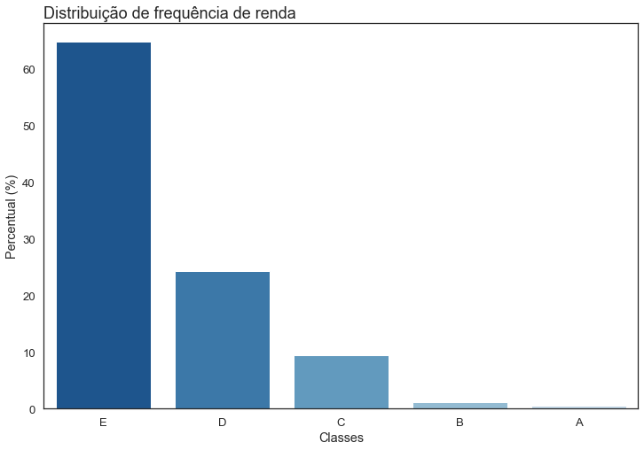

```python
#Plotando a frequência de cada classe
_ =barplotfunc(data=percentual, x='Classes', y='Renda', title='Distribuição de frequência de renda',ylabel='Percentual (%)')
```

> **Insight**: Como fica claro, infelizmente, a classe mais populosa é a E. Lembrando que a classe é tem renda de até **2 salários mínimos.**
- Visualizando a Renda

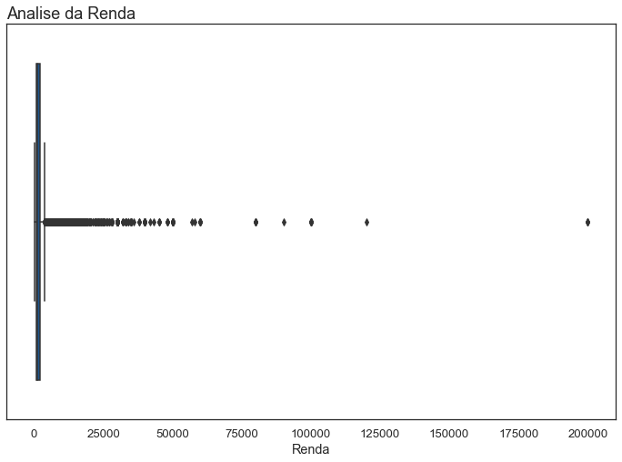

```python
#Plotando boxplot dos dados gerais sobre a renda
_ = outlierfunc(data=dados, x='Renda', ylabel=None, title="Analise da Renda")
```

> Há possíveis outliers, mas como se trata de renda, vamos filtrar para um valor menor e obter uma melhor visualização.
- Identificando os quartis

```python
#Criando intervalos
Q1 = dados.Renda.quantile(0.25)
Q2 = dados.Renda.quantile(0.50)
Q3 = dados.Renda.quantile(0.75)

IQQ = Q3 - Q1
limite_inferior = Q1 - 1.5 * IQQ
limite_superior = Q3 + 1.5 * IQQ
```

```python
#Exibindo intervalos
print(Q1,Q2,Q3)
```

```
788.0 1200.0 2000.0
```

```python
#Printando limite superior
limite_superior
```

```
3818.0
```

> **Insight**: Analisando os quartis:
> - 25% da população ganha até 788,00;
> - 50% até 1.200,00;
> - 75% até 2.000,00

> **Insitght**: Observa-se que, no ano dde 2015, acima de **R$ 3.818,00** já são valores 'descrepantes' para a sociedade brasileira.

### 3.2 Analisando Renda e Sexo.

Objetivo : Separar as rendas de R$ 3.818,00 para baixo e para cima e exploarar analises baseando no sexo.

- Construindo dataframe com renda de R$ 3.818,00 ou menos

```python
#Criando dataframe com renda inferior ao limite
dfRendamenor = dados.query("Renda <=3818").groupby(["Sexo", "Cor"]).Renda.mean().reset_index()
dfRendamenor = pd.DataFrame(dfRendamenor)
```

```python
#Exibindo a renda
dfRendamenor
```

|  | Sexo | Cor | Renda |
| --- | --- | --- | --- |
| 0 | Feminino | Amarela | 1418.670330 |
| 1 | Feminino | Branca | 1248.056715 |
| 2 | Feminino | Indígena | 872.075269 |
| 3 | Feminino | Parda | 920.138728 |
| 4 | Feminino | Preta | 945.759670 |
| 5 | Masculino | Amarela | 1799.713287 |
| 6 | Masculino | Branca | 1546.750533 |
| 7 | Masculino | Indígena | 910.235772 |
| 8 | Masculino | Parda | 1214.094003 |
| 9 | Masculino | Preta | 1255.918935 |

- Construindo dataframe para rendas superiores a R$ 3.818,00

```python
#Criando df com as rendas superiores ao limite
dfRendaMaior = dados.query("Renda > 3818").groupby(["Sexo", "Cor"]).Renda.mean().to_frame()
```

```python
#Resetando o index do dataframe
dfRendaMaior.reset_index(inplace=True)
```

```python
#Data frame final
dfRendaMaior
```

|  | Sexo | Cor | Renda |
| --- | --- | --- | --- |
| 0 | Feminino | Amarela | 8657.692308 |
| 1 | Feminino | Branca | 7720.714286 |
| 2 | Feminino | Indígena | 20975.000000 |
| 3 | Feminino | Parda | 6703.134855 |
| 4 | Feminino | Preta | 6569.979381 |
| 5 | Masculino | Amarela | 9356.847826 |
| 6 | Masculino | Branca | 8540.669790 |
| 7 | Masculino | Indígena | 5300.000000 |
| 8 | Masculino | Parda | 7143.542220 |
| 9 | Masculino | Preta | 6603.351955 |

- Boxplot da renda por sexo de todo data frame.

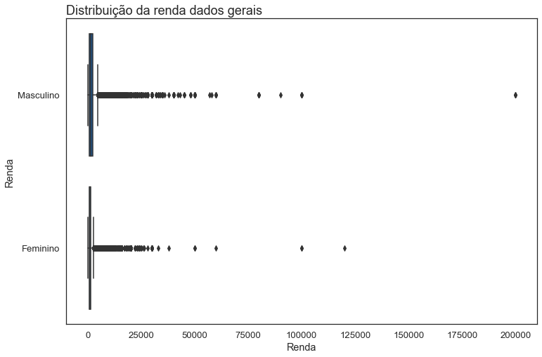

```python
#Boxplot dos dados gerais analisando renda e sexo
_ = outlierfunc(data=dados, x="Renda", y="Sexo", title="Distribuição da renda dados gerais",
             ylabel="Renda")
```

- Filtrando renda de até R$3.818,00

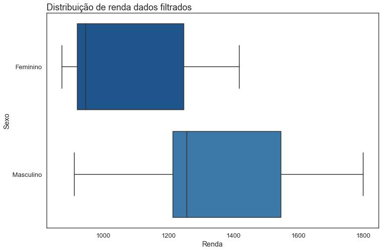

```python
#Boxplot analisando o df com renda menor ao limite
_ = outlierfunc(data=dfRendamenor, x="Renda", y="Sexo", title="Distribuição de renda dados filtrados", ylabel="Sexo")
```

> Insight: Os homens tem uma renda maior (média) que as mulheres. Dataset analisado: Renda de até R$3.818,00
- Comparando os dados de renda gerais.

```python
#Media geral dos dados

dfMediaGeral = dados.groupby("Sexo").Renda.mean().round(2).reset_index()
```

```python
#Exibindo media geral
dfMediaGeral
```

|  | Sexo | Renda |
| --- | --- | --- |
| 0 | Feminino | 1566.85 |
| 1 | Masculino | 2192.44 |

```python
variacao = ((2192.44 - 1566.85) / 1566.85 )*100
variacao
```

```
39.92660433353545
```

> **Insight**:Os homens ganhavam cerca de **40%** a mais do que as mulheres no Brasil, em 2015.

### 3.3 Teste de hipótese

Realizando um teste de hipótese para confirmar se os homens ganham mais que as mulheres, em média, no ano de 2015. Será realizado uma amostra estratificada dos **dados**.  
Para esse teste foi gerado uma amostra aleatória de 1000 homens e mulheres.

```python
dados
```

|  | UF | Sexo | Idade | Cor | Anos de Estudo | Renda |
| --- | --- | --- | --- | --- | --- | --- |
| 0 | Rondônia | Masculino | 23 | Parda | 12 | 800 |
| 1 | Rondônia | Feminino | 23 | Branca | 12 | 1150 |
| 2 | Rondônia | Feminino | 35 | Parda | 15 | 880 |
| 3 | Rondônia | Masculino | 46 | Branca | 6 | 3500 |
| 4 | Rondônia | Feminino | 47 | Parda | 9 | 150 |
| ... | ... | ... | ... | ... | ... | ... |
| 76835 | Distrito Federal | Feminino | 46 | Branca | 11 | 812 |
| 76836 | Distrito Federal | Masculino | 30 | Preta | 7 | 1500 |
| 76837 | Distrito Federal | Masculino | 32 | Parda | 12 | 1300 |
| 76838 | Distrito Federal | Masculino | 57 | Parda | 4 | 1500 |
| 76839 | Distrito Federal | Masculino | 38 | Parda | 4 | 900 |

76840 rows × 6 columns

```python
#Exibindo dados dos homens e mulheres
dados.loc[lambda x: dados.Sexo == 'Masculino']
dados.loc[lambda x: dados.Sexo == 'Feminino']
```

|  | UF | Sexo | Idade | Cor | Anos de Estudo | Renda |
| --- | --- | --- | --- | --- | --- | --- |
| 1 | Rondônia | Feminino | 23 | Branca | 12 | 1150 |
| 2 | Rondônia | Feminino | 35 | Parda | 15 | 880 |
| 4 | Rondônia | Feminino | 47 | Parda | 9 | 150 |
| 5 | Rondônia | Feminino | 34 | Parda | 12 | 790 |
| 7 | Rondônia | Feminino | 60 | Parda | 12 | 1700 |
| ... | ... | ... | ... | ... | ... | ... |
| 76827 | Distrito Federal | Feminino | 41 | Branca | 16 | 10000 |
| 76831 | Distrito Federal | Feminino | 44 | Branca | 16 | 30000 |
| 76832 | Distrito Federal | Feminino | 49 | Branca | 12 | 5000 |
| 76834 | Distrito Federal | Feminino | 35 | Preta | 1 | 1100 |
| 76835 | Distrito Federal | Feminino | 46 | Branca | 11 | 812 |

23590 rows × 6 columns

```python
#Exibindo frequência
dados.Sexo.value_counts()
```

```
Masculino    53250
Feminino     23590
Name: Sexo, dtype: int64
```

```python
dfHomens = pd.DataFrame(dados.loc[lambda x: dados['Sexo'] == 'Masculino'].Renda)
dfMulheres = pd.DataFrame(dados.loc[lambda x: dados['Sexo'] == 'Feminino'].Renda)
dfHomens
```

|  | Renda |
| --- | --- |
| 0 | 800 |
| 3 | 3500 |
| 6 | 3150 |
| 9 | 1150 |
| 13 | 2000 |
| ... | ... |
| 76833 | 1900 |
| 76836 | 1500 |
| 76837 | 1300 |
| 76838 | 1500 |
| 76839 | 900 |

53250 rows × 1 columns

```python
dfMulheres
```

|  | Renda |
| --- | --- |
| 1 | 1150 |
| 2 | 880 |
| 4 | 150 |
| 5 | 790 |
| 7 | 1700 |
| ... | ... |
| 76827 | 10000 |
| 76831 | 30000 |
| 76832 | 5000 |
| 76834 | 1100 |
| 76835 | 812 |

23590 rows × 1 columns

```python
#Gerando amostras aleatórias
dfHomens = dfHomens.sample(n = 1000)
dfMulheres = dfMulheres.sample(n=1000)
```

#### Os dados seguem a mesma distribuição dos dados.

Formulação das hipóteses:  
u1: Homens  
u2: Mulheres

$H0$: As mulheres ganham mais ou igual aos homens

$HA$: Os homens ganhão mais que as mulheres.

$H0$ : u1 $\leq$ u2  
$H1$ : u1 $>$ u2

#### Como o desvio padrâo é desconhecido, e o tamanho da amostra é maior que 30, será utilizado o teste Z.

```python
#Separação dos dados
#Média masculina
mediaH = dfHomens.Renda.mean()

#Média feminina
mediaF = dfMulheres.Renda.mean()

#Exibindo médias de salários
print(f"Média masculina: R${mediaH:.2f}, média feminina R${mediaF:.2f}")
```

```
Média masculina: R$2289.69, média feminina R$1514.72
```

```python
#Estabelecendo nível de significância
sig = 0.01
n_h = 500  #Quantidade de homens no data_teste
n_f = 500   #Quantidade  de mulheres no data_teste
d_0 = 0      #0 pois declaro que não há diferença
graus_de_liberdade = (n_h + n_f ) - 2 #graus de liberdade
std_homens = dfHomens.Renda.std()
std_mulheres = dfMulheres.Renda.std()
```

```python
#Calculando z teste
numerador = (mediaH - mediaF ) - d_0
denominador = np.sqrt((std_homens ** 2 / n_h) + std_mulheres ** 2 / n_f)

z = numerador / denominador
z
```

```
4.181585919643424
```

```python
#Importando biblioteca
from statsmodels.stats.weightstats import DescrStatsW, CompareMeans

#Teste homens
testH = DescrStatsW(dfHomens)
#Teste mulheres
testM = DescrStatsW(dfMulheres)

#comparando os testes
testA = testH.get_compare(testM)
testB = CompareMeans(testH, testM)

#Extraindo p_valor
z, p_valor = testA.ztest_ind(alternative='larger', value=0)
print(z)
```

```
[5.91365552]
```

```python
p_valor[0]
```

```
1.6729865004069304e-09
```

#### Concluindo com p_value

```python
p_valor <= sig
```

```
array([ True])
```

**Pode-se concluir, considerando-se um nível de 1% de significância, que o salário das mulheres NÃO são maiores ou iguais aos salários do sexo Masculino.**

### 3.4 Analisando Renda, Sexo e Etnia

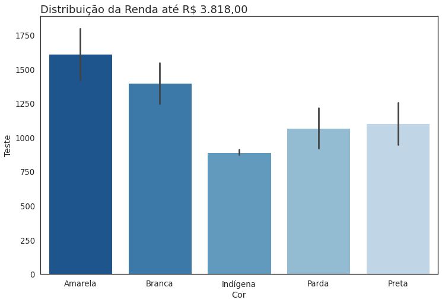

```python
_ = barplotfunc(data =dfRendamenor, x='Cor', y="Renda",
                title="Distribuição da Renda até R$ 3.818,00", ylabel="Teste")
```

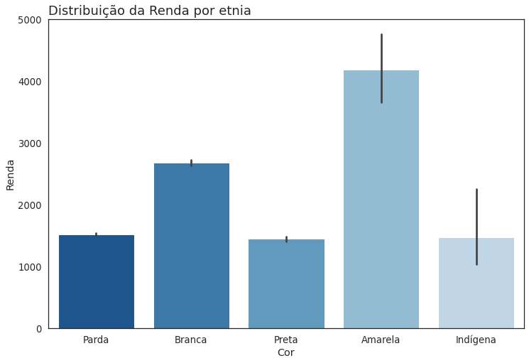

```python
_ = barplotfunc(data =dados, x="Cor", y="Renda",
                title="Distribuição da Renda por etnia", ylabel="Renda")
```

```python
dados.query("Cor == 'Amarela'").Renda.mean()
```

```
4182.920454545455
```

```python
dados.query("Cor == 'Amarela'").Renda.max()
```

```
50000
```

```python
dados.query("Renda == 50000 and Cor == 'Amarela'")
```

|  | UF | Sexo | Idade | Cor | Anos de Estudo | Renda |
| --- | --- | --- | --- | --- | --- | --- |
| 9343 | Pará | Masculino | 59 | Amarela | 12 | 50000 |

```python
dfEtniaAmarelo = dados.query("Cor == 'Amarela'")
dfEtniaAmarelo.reset_index(inplace=True)
```

```python
dfEtniaAmarelo.columns
```

```
Index(['index', 'UF', 'Sexo', 'Idade', 'Cor', 'Anos de Estudo', 'Renda'], dtype='object')
```

```python
dfEtniaAmarelo.drop(columns="index", inplace=True)
```

```python
dfEtniaAmarelo.head()
```

|  | UF | Sexo | Idade | Cor | Anos de Estudo | Renda |
| --- | --- | --- | --- | --- | --- | --- |
| 0 | Rondônia | Masculino | 64 | Amarela | 5 | 600 |
| 1 | Rondônia | Masculino | 53 | Amarela | 8 | 1800 |
| 2 | Rondônia | Masculino | 34 | Amarela | 16 | 8000 |
| 3 | Rondônia | Feminino | 45 | Amarela | 5 | 640 |
| 4 | Rondônia | Masculino | 33 | Amarela | 5 | 1250 |

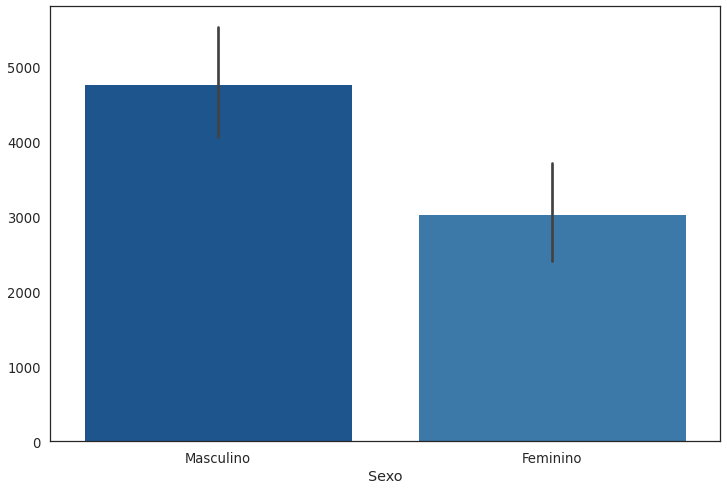

```python
_=barplotfunc(data=dfEtniaAmarelo, x="Sexo", y="Renda", title=None, ylabel=None)
```

```python
dfEtniaAmarelo.sort_values("Renda", ascending=False)
```

|  | UF | Sexo | Idade | Cor | Anos de Estudo | Renda |
| --- | --- | --- | --- | --- | --- | --- |
| 31 | Pará | Masculino | 59 | Amarela | 12 | 50000 |
| 339 | Goiás | Masculino | 37 | Amarela | 12 | 30000 |
| 242 | Paraná | Masculino | 63 | Amarela | 16 | 28000 |
| 179 | São Paulo | Masculino | 44 | Amarela | 16 | 20000 |
| 22 | Pará | Masculino | 50 | Amarela | 16 | 20000 |
| ... | ... | ... | ... | ... | ... | ... |
| 74 | Bahia | Feminino | 34 | Amarela | 5 | 40 |
| 25 | Pará | Feminino | 64 | Amarela | 16 | 0 |
| 113 | São Paulo | Feminino | 64 | Amarela | 5 | 0 |
| 336 | Goiás | Masculino | 62 | Amarela | 9 | 0 |
| 284 | Rio Grande do Sul | Masculino | 66 | Amarela | 2 | 0 |

352 rows × 6 columns

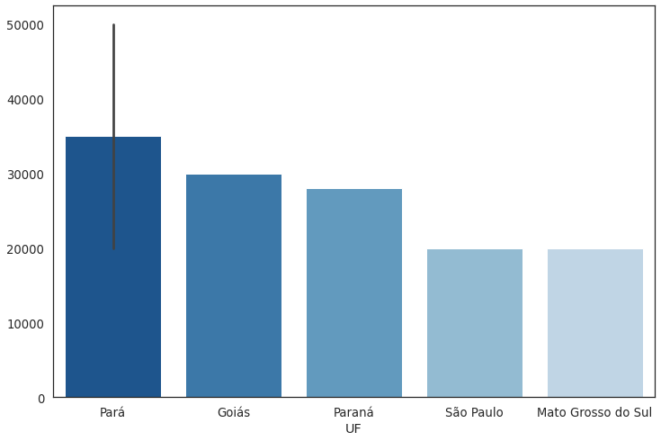

```python
_=barplotfunc(data=dfEtniaAmarelo.sort_values("Renda", ascending=False)[:7],
              x="UF", y="Renda", title=None, ylabel=None)
```

> **Insight**: O Pará é o estado com maior renda média dessa Etnia. Deve analisar se o estado do Pará está entre os primeiros que mais pagam, dos dados gerais.
- Criando um grupo para analisar os demais estados.

```python
dfAgrupados=dados.groupby(["UF", "Sexo", "Cor"])["Renda"].mean()
```

```python
dfAgrupados = pd.DataFrame(dfAgrupados).reset_index()
```

```python
dfAgrupados.sort_values("Renda", ascending=False)
```

|  | UF | Sexo | Cor | Renda |
| --- | --- | --- | --- | --- |
| 189 | Rio de Janeiro | Feminino | Indígena | 18784.000000 |
| 149 | Pará | Masculino | Amarela | 11135.714286 |
| 220 | Santa Catarina | Masculino | Amarela | 9250.000000 |
| 105 | Mato Grosso do Sul | Feminino | Amarela | 7373.333333 |
| 177 | Rio Grande do Sul | Feminino | Amarela | 6175.000000 |
| ... | ... | ... | ... | ... |
| 92 | Maranhão | Masculino | Indígena | 375.000000 |
| 0 | Acre | Feminino | Amarela | 300.000000 |
| 2 | Acre | Feminino | Indígena | 250.000000 |
| 225 | Sergipe | Feminino | Amarela | 200.000000 |
| 87 | Maranhão | Feminino | Indígena | 150.000000 |

252 rows × 4 columns

```python
dfAgrupados["UF"].unique()
```

```
array(['Acre', 'Alagoas', 'Amapá', 'Amazonas', 'Bahia', 'Ceará',
       'Distrito Federal', 'Espírito Santo', 'Goiás', 'Maranhão',
       'Mato Grosso', 'Mato Grosso do Sul', 'Minas Gerais', 'Paraná',
       'Paraíba', 'Pará', 'Pernambuco', 'Piauí', 'Rio Grande do Norte',
       'Rio Grande do Sul', 'Rio de Janeiro', 'Rondônia', 'Roraima',
       'Santa Catarina', 'Sergipe', 'São Paulo', 'Tocantins'],
      dtype=object)
```

```python
dfAgrupados.loc[lambda df: dfAgrupados['UF']== 'Distrito Federal']
```

|  | UF | Sexo | Cor | Renda |
| --- | --- | --- | --- | --- |
| 57 | Distrito Federal | Feminino | Amarela | 6000.000000 |
| 58 | Distrito Federal | Feminino | Branca | 4308.846386 |
| 59 | Distrito Federal | Feminino | Indígena | 633.333333 |
| 60 | Distrito Federal | Feminino | Parda | 2628.223684 |
| 61 | Distrito Federal | Feminino | Preta | 1950.802469 |
| 62 | Distrito Federal | Masculino | Amarela | 5371.428571 |
| 63 | Distrito Federal | Masculino | Branca | 5848.899811 |
| 64 | Distrito Federal | Masculino | Indígena | 2000.000000 |
| 65 | Distrito Federal | Masculino | Parda | 4472.861702 |
| 66 | Distrito Federal | Masculino | Preta | 2877.868421 |

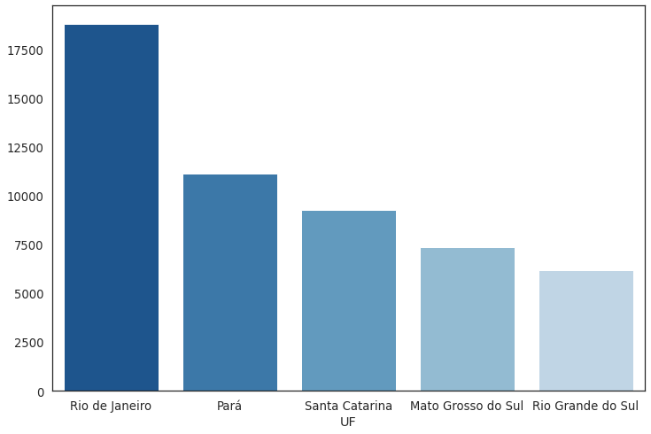

```python
_=barplotfunc(data=dfAgrupados.sort_values("Renda", ascending=False)[:5],
            x="UF", y="Renda", title=None, ylabel=None)
```

### 3.5 Analisando correlação de anos de estudo e renda.

- Criando dataframe para analisar os anos de estudo com a renda.

```python
dfAnos = dados.groupby("Anos de Estudo").Renda.mean().to_frame().reset_index()
```

```python
dfAnos
```

|  | Anos de Estudo | Renda |
| --- | --- | --- |
| 0 | 1 | 732.994187 |
| 1 | 2 | 806.524496 |
| 2 | 3 | 842.560209 |
| 3 | 4 | 980.044275 |
| 4 | 5 | 1150.439293 |
| 5 | 6 | 1183.575683 |
| 6 | 7 | 1284.082618 |
| 7 | 8 | 1289.166233 |
| 8 | 9 | 1437.744862 |
| 9 | 10 | 1315.685870 |
| 10 | 11 | 1495.901322 |
| 11 | 12 | 1841.671287 |
| 12 | 13 | 2185.769063 |
| 13 | 14 | 2758.774142 |
| 14 | 15 | 3099.840058 |
| 15 | 16 | 5242.443353 |
| 16 | 17 | 1071.717277 |

```python
dfAnos.describe()
```

|  | Anos de Estudo | Renda |
| --- | --- | --- |
| count | 17.000000 | 17.000000 |
| mean | 9.000000 | 1689.349072 |
| std | 5.049752 | 1130.095815 |
| min | 1.000000 | 732.994187 |
| 25% | 5.000000 | 1071.717277 |
| 50% | 9.000000 | 1289.166233 |
| 75% | 13.000000 | 1841.671287 |
| max | 17.000000 | 5242.443353 |

- Plotando o gáfico para analisar a tendência

.

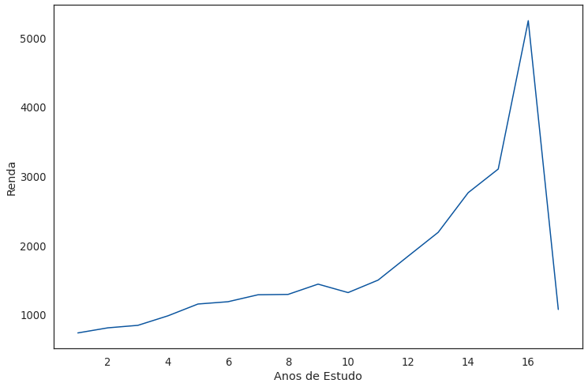

```python
plt.figure(figsize=(12,8))
ax =sns.lineplot(data=dfAnos, x='Anos de Estudo', y = "Renda")
```

```python
dfAnos.corr()
```

|  | Anos de Estudo | Renda |
| --- | --- | --- |
| Anos de Estudo | 1.000000 | 0.687397 |
| Renda | 0.687397 | 1.000000 |

[figure not shown]

```python
ax =sns.lmplot(data=dfAnos, x="Anos de Estudo", y="Renda")
ax.figure.set_size_inches(12, 8)
ax.fig.suptitle("Renda e anos de estudo",fontsize = 18, x=0.34, y=1)
plt.show()
```

> **Insight**: A uma correlação moderada (0.69) entre anos de estudo e renda. Quanto mais anos de estudo, maior a renda.  
> Ha uma queda no ano 17, porém pode ser um outlier.
- Explorando explicações para a queda de renda aos 17 anos de estudo.

```python
df17 = dados.loc[dados['Anos de Estudo']== 17]
df17
```

|  | UF | Sexo | Idade | Cor | Anos de Estudo | Renda |
| --- | --- | --- | --- | --- | --- | --- |
| 74 | Rondônia | Masculino | 41 | Parda | 17 | 2000 |
| 188 | Rondônia | Masculino | 38 | Parda | 17 | 1900 |
| 343 | Rondônia | Feminino | 47 | Branca | 17 | 788 |
| 1160 | Rondônia | Masculino | 26 | Branca | 17 | 1200 |
| 1261 | Rondônia | Feminino | 38 | Parda | 17 | 500 |
| ... | ... | ... | ... | ... | ... | ... |
| 75844 | Distrito Federal | Feminino | 56 | Parda | 17 | 300 |
| 76041 | Distrito Federal | Feminino | 22 | Branca | 17 | 788 |
| 76575 | Distrito Federal | Feminino | 45 | Preta | 17 | 1200 |
| 76597 | Distrito Federal | Feminino | 58 | Preta | 17 | 3000 |
| 76674 | Distrito Federal | Feminino | 36 | Parda | 17 | 1200 |

191 rows × 6 columns

```python
df17mean = df17.loc[dados['Anos de Estudo']== 17].mean().to_frame().reset_index().round(2)
```

```python
df17mean
```

|  | index | 0 |
| --- | --- | --- |
| 0 | Idade | 38.35 |
| 1 | Anos de Estudo | 17.00 |
| 2 | Renda | 1071.72 |

```python
df17.loc[dados["Renda"] < 1000]
```

|  | UF | Sexo | Idade | Cor | Anos de Estudo | Renda |
| --- | --- | --- | --- | --- | --- | --- |
| 343 | Rondônia | Feminino | 47 | Branca | 17 | 788 |
| 1261 | Rondônia | Feminino | 38 | Parda | 17 | 500 |
| 1610 | Acre | Masculino | 35 | Parda | 17 | 700 |
| 2336 | Acre | Feminino | 37 | Parda | 17 | 0 |
| 2887 | Amazonas | Masculino | 38 | Parda | 17 | 500 |
| ... | ... | ... | ... | ... | ... | ... |
| 73756 | Goiás | Feminino | 31 | Parda | 17 | 788 |
| 74616 | Goiás | Feminino | 35 | Parda | 17 | 788 |
| 75779 | Distrito Federal | Feminino | 40 | Branca | 17 | 840 |
| 75844 | Distrito Federal | Feminino | 56 | Parda | 17 | 300 |
| 76041 | Distrito Federal | Feminino | 22 | Branca | 17 | 788 |

106 rows × 6 columns

> Hipótese : Aos 17 de Estudo há uma queda de renda, pois pode estar desempregada(o) e faz "bicos" para sobreviver.  
> Para confirmar essa hipótese, seria necessário obter mais dados, como não há possibilidade essa hipótese ficára em aberto.
- Explorando sexos que mais estudam.

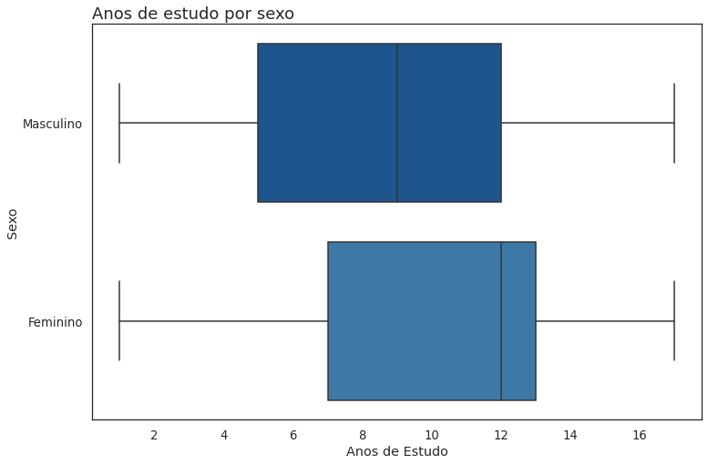

```python
_= outlierfunc(data=dados, x='Anos de Estudo', y ='Sexo', title ="Anos de estudo por sexo"
            ,ylabel='Sexo')
```

> **Insight**: As mulheres tem um maior período de estudo comparado aos homens.
> - Mesmo assim, elas ganham menos.

### 3.6 Analisando a renda por estado.

- Analisando onde os homems ganham mais.

```python
dfMasc = dados.query('Sexo == "Masculino"')
```

```python
dfRendaMasc = dfMasc.groupby("UF").Renda.mean().sort_values(ascending=False)
dfRendaMasc = pd.DataFrame(dfRendaMasc).reset_index()
dfRendaMasc
```

|  | UF | Renda |
| --- | --- | --- |
| 0 | Distrito Federal | 4863.366321 |
| 1 | São Paulo | 2947.742872 |
| 2 | Rio de Janeiro | 2777.552792 |
| 3 | Paraná | 2767.429211 |
| 4 | Santa Catarina | 2688.304121 |
| 5 | Mato Grosso do Sul | 2603.484296 |
| 6 | Rio Grande do Sul | 2488.392840 |
| 7 | Mato Grosso | 2335.347994 |
| 8 | Minas Gerais | 2283.158288 |
| 9 | Goiás | 2222.632558 |
| 10 | Espírito Santo | 2129.324226 |
| 11 | Amapá | 1930.396970 |
| 12 | Rondônia | 1921.209139 |
| 13 | Tocantins | 1912.509395 |
| 14 | Roraima | 1875.788136 |
| 15 | Pernambuco | 1664.931211 |
| 16 | Acre | 1635.342407 |
| 17 | Bahia | 1557.495271 |
| 18 | Amazonas | 1539.989460 |
| 19 | Pará | 1509.741894 |
| 20 | Rio Grande do Norte | 1459.050074 |
| 21 | Paraíba | 1364.993348 |
| 22 | Ceará | 1341.616974 |
| 23 | Sergipe | 1205.569857 |
| 24 | Maranhão | 1165.172097 |
| 25 | Alagoas | 1157.752593 |
| 26 | Piauí | 1146.710618 |

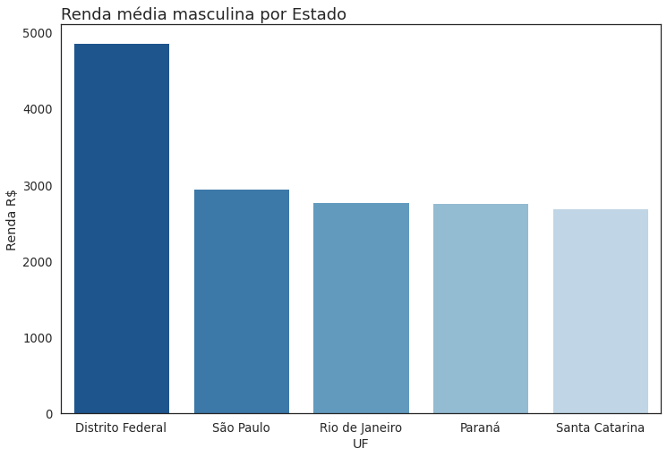

```python
_ = barplotfunc(data=dfRendaMasc[0:5], x="UF", y="Renda", title="Renda média masculina por Estado",
                ylabel="Renda R$")
```

> **Insight**: O Distrito Federal é o estado que mais paga, seguido por São Paulo e Rio de Janeiro em relação aos **Homens**
- Analisando onde as mulheres ganham mais.

```python
dados
```

|  | UF | Sexo | Idade | Cor | Anos de Estudo | Renda |
| --- | --- | --- | --- | --- | --- | --- |
| 0 | Rondônia | Masculino | 23 | Parda | 12 | 800 |
| 1 | Rondônia | Feminino | 23 | Branca | 12 | 1150 |
| 2 | Rondônia | Feminino | 35 | Parda | 15 | 880 |
| 3 | Rondônia | Masculino | 46 | Branca | 6 | 3500 |
| 4 | Rondônia | Feminino | 47 | Parda | 9 | 150 |
| ... | ... | ... | ... | ... | ... | ... |
| 76835 | Distrito Federal | Feminino | 46 | Branca | 11 | 812 |
| 76836 | Distrito Federal | Masculino | 30 | Preta | 7 | 1500 |
| 76837 | Distrito Federal | Masculino | 32 | Parda | 12 | 1300 |
| 76838 | Distrito Federal | Masculino | 57 | Parda | 4 | 1500 |
| 76839 | Distrito Federal | Masculino | 38 | Parda | 4 | 900 |

76840 rows × 6 columns

```python
dfRendaMulheres = dados.query("Sexo == 'Feminino'")
dfRendaMulheres
```

|  | UF | Sexo | Idade | Cor | Anos de Estudo | Renda |
| --- | --- | --- | --- | --- | --- | --- |
| 1 | Rondônia | Feminino | 23 | Branca | 12 | 1150 |
| 2 | Rondônia | Feminino | 35 | Parda | 15 | 880 |
| 4 | Rondônia | Feminino | 47 | Parda | 9 | 150 |
| 5 | Rondônia | Feminino | 34 | Parda | 12 | 790 |
| 7 | Rondônia | Feminino | 60 | Parda | 12 | 1700 |
| ... | ... | ... | ... | ... | ... | ... |
| 76827 | Distrito Federal | Feminino | 41 | Branca | 16 | 10000 |
| 76831 | Distrito Federal | Feminino | 44 | Branca | 16 | 30000 |
| 76832 | Distrito Federal | Feminino | 49 | Branca | 12 | 5000 |
| 76834 | Distrito Federal | Feminino | 35 | Preta | 1 | 1100 |
| 76835 | Distrito Federal | Feminino | 46 | Branca | 11 | 812 |

23590 rows × 6 columns

```python
dfRendaMulheresplot = dfRendaMulheres.groupby("UF").Renda.mean().sort_values(ascending=False)
dfRendaMulheresplot = pd.DataFrame(dfRendaMulheresplot).reset_index()
```

```python
dfRendaMulheresplot
```

|  | UF | Renda |
| --- | --- | --- |
| 0 | Distrito Federal | 3269.883895 |
| 1 | Rio de Janeiro | 1971.532508 |
| 2 | Rio Grande do Sul | 1960.845376 |
| 3 | São Paulo | 1950.176471 |
| 4 | Paraná | 1796.263244 |
| 5 | Santa Catarina | 1792.114130 |
| 6 | Espírito Santo | 1752.707022 |
| 7 | Amapá | 1736.164835 |
| 8 | Roraima | 1608.112903 |
| 9 | Mato Grosso | 1604.293651 |
| 10 | Mato Grosso do Sul | 1519.891832 |
| 11 | Minas Gerais | 1489.616576 |
| 12 | Rondônia | 1414.854637 |
| 13 | Tocantins | 1381.798851 |
| 14 | Goiás | 1339.376392 |
| 15 | Pernambuco | 1252.239812 |
| 16 | Amazonas | 1235.832849 |
| 17 | Bahia | 1175.015175 |
| 18 | Pará | 1131.884114 |
| 19 | Acre | 1128.615063 |
| 20 | Paraíba | 1119.704301 |
| 21 | Alagoas | 1105.473684 |
| 22 | Ceará | 1085.795053 |
| 23 | Rio Grande do Norte | 1080.676871 |
| 24 | Piauí | 899.858757 |
| 25 | Sergipe | 877.150794 |
| 26 | Maranhão | 723.752542 |

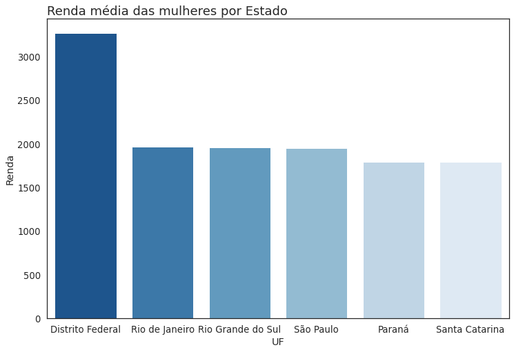

```python
_= barplotfunc(data=dfRendaMulheresplot[:6], x="UF", y="Renda", title="Renda média das mulheres por Estado", ylabel="Renda")
```

### 3.7 Analisando renda do Distrito Federal.

```python
dfDistrito = dados[(dados.UF =='Distrito Federal')]
dfDistrito
```

|  | UF | Sexo | Idade | Cor | Anos de Estudo | Renda |
| --- | --- | --- | --- | --- | --- | --- |
| 74786 | Distrito Federal | Feminino | 39 | Branca | 16 | 8300 |
| 74787 | Distrito Federal | Feminino | 37 | Parda | 16 | 10000 |
| 74788 | Distrito Federal | Masculino | 46 | Branca | 16 | 14500 |
| 74789 | Distrito Federal | Masculino | 53 | Parda | 16 | 10000 |
| 74790 | Distrito Federal | Masculino | 33 | Branca | 16 | 12000 |
| ... | ... | ... | ... | ... | ... | ... |
| 76835 | Distrito Federal | Feminino | 46 | Branca | 11 | 812 |
| 76836 | Distrito Federal | Masculino | 30 | Preta | 7 | 1500 |
| 76837 | Distrito Federal | Masculino | 32 | Parda | 12 | 1300 |
| 76838 | Distrito Federal | Masculino | 57 | Parda | 4 | 1500 |
| 76839 | Distrito Federal | Masculino | 38 | Parda | 4 | 900 |

2054 rows × 6 columns

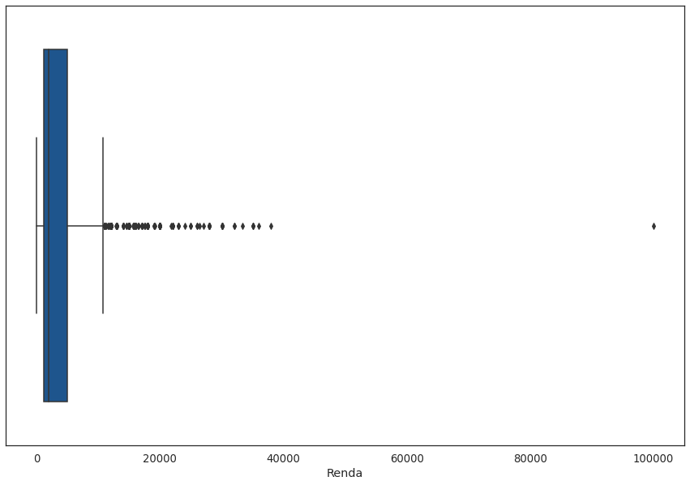

```python
ax = sns.boxplot(x = 'Renda', data = dfDistrito, orient = 'h')
ax.figure.set_size_inches(15, 10)
```

Analisando os outliers do Distrito Federal

```python
Q1 = dfDistrito.Renda.quantile(0.25)
Q2 = dfDistrito.Renda.quantile(0.50)
Q3 = dfDistrito.Renda.quantile(0.75)

limite_inferior =  Q1 - 1.5 * (Q3 - Q1)
limite_superior = Q3 + 1.5 * (Q3 - Q1)
```

```python
limite_inferior
limite_superior.round(2)
```

```
10846.62
```

Como podemos ver, o limite superior é bem alto para o padrão brasileiro. Totalizando R$ 10.846,62

```python
dfDistrito.describe()
```

|  | Idade | Anos de Estudo | Renda |
| --- | --- | --- | --- |
| count | 2054.000000 | 2054.000000 | 2054.000000 |
| mean | 42.734177 | 11.910419 | 4241.954722 |
| std | 11.556609 | 4.148458 | 5550.463338 |
| min | 17.000000 | 1.000000 | 0.000000 |
| 25% | 34.000000 | 9.000000 | 1102.250000 |
| 50% | 42.000000 | 12.000000 | 2000.000000 |
| 75% | 51.000000 | 16.000000 | 5000.000000 |
| max | 81.000000 | 17.000000 | 100000.000000 |

### 3.8 Analisando anos de estudo por Estado.

```python
dfEstudos = dados.groupby(['UF'])['Anos de Estudo'].mean().to_frame().reset_index()
dfEstudos
```

|  | UF | Anos de Estudo |
| --- | --- | --- |
| 0 | Acre | 8.398079 |
| 1 | Alagoas | 7.838317 |
| 2 | Amapá | 10.050781 |
| 3 | Amazonas | 9.361741 |
| 4 | Bahia | 8.725730 |
| 5 | Ceará | 8.665079 |
| 6 | Distrito Federal | 11.910419 |
| 7 | Espírito Santo | 9.466578 |
| 8 | Goiás | 9.435883 |
| 9 | Maranhão | 7.518747 |
| 10 | Mato Grosso | 9.472778 |
| 11 | Mato Grosso do Sul | 9.509028 |
| 12 | Minas Gerais | 9.129846 |
| 13 | Paraná | 10.084252 |
| 14 | Paraíba | 8.165620 |
| 15 | Pará | 8.672286 |
| 16 | Pernambuco | 9.214921 |
| 17 | Piauí | 7.014038 |
| 18 | Rio Grande do Norte | 8.823227 |
| 19 | Rio Grande do Sul | 10.104556 |
| 20 | Rio de Janeiro | 10.547516 |
| 21 | Rondônia | 8.811971 |
| 22 | Roraima | 9.916667 |
| 23 | Santa Catarina | 10.226813 |
| 24 | Sergipe | 7.337995 |
| 25 | São Paulo | 10.639045 |
| 26 | Tocantins | 9.027565 |

```python
dfEstudos = dfEstudos.sort_values(by = 'Anos de Estudo', ascending = False)
```

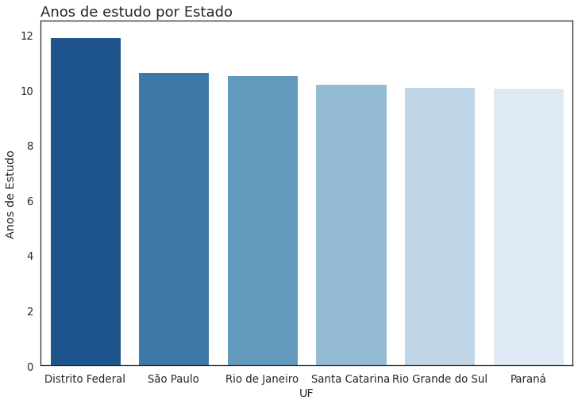

```python
_=barplotfunc(data=dfEstudos[0:6], x="UF", y="Anos de Estudo", title="Anos de estudo por Estado", ylabel="Anos de Estudo")
```

> Insight: O Distrito Federal é o estado que contém os estudantes que dedicam mais anos ao estudos, seguido por São Paulo e Rio de Janeiro.

# 4. Conclusão

### 4.1 Insights:

Esse projeto foi uma exploração dos dados para buscar insights sobre salários.

Nesse projeto, foram levantados algumas descobertas importantes. Tais como:

- A classe mais populosa é a E. Lembrando que essa classe pertence aos trabalhadores **2 salários mínimos. Na época o salário mínimo era de 788,00 reais.**
- No ano de 2015, acima de **3.818,00** já era considerado valores 'discrepantes' para a sociedade brasileira.
- Os homens tem uma renda maior (média) que as mulheres. Renda de até 3.818,00
- Analisado todo o dados, sem filtragem de renda até 3818,00. Os homens ganham **40%** a mais que as mulheres em 2015.
- A uma correlação moderada (0.69) entre anos de estudo e renda. Quanto mais anos de estudo, maior a renda.
- As mulheres **estudam mais** que os homens, quantidades de anos, e **ganham menos**
- O Distrito Federal contém a **maior média** de salário para ambos os sexos **Masculino e Feminino**.
- No Distrito Federal há uma **média** de:
  1. 42 anos de idade;
  2. 12 anos de estudo;
  3. R$ 4.242,00 de renda
- No Distrito Federal contém as pessoas que estudam por mais tempo.

### 4.2 Hipóteses.

Para essa análise, foi realizado um teste de hipótese para confirmar a desigualdade entre os salários dos sexos masculino e feminino.

Vide o notebook.

### 4.3 Encerramento

Essa foi uma análise exploratória que o principal objetivo erá analisar a diferença de salários entre os sexos. Com o teste de hipótese foi possível ter uma posição concreta estatisticamente.

**Redes Sociais**: [Contato](https://linktr.ee/marcus_bernardo)